# A3: SPL Library Checkouts

### Introduction

This data described the number of checkout materials both in digital and physical forms that has been checked out by individuals from 2017 to 2023 with items checked out at least 10 times a month. I especially liked the book The Hobbit, because not only did I read the book thoroughly, but also watched the movie a few times. The plots and settings of the data are innovative and just feels different to other movies or novels. So I did some investigations to analyze the trends and some interesting information of the book.

### Summary Information

The development of technology with recent COVID cases drastically impacted society, pushed public interest from physical hard copies to digital electronic copies of files. From a data published by the Seattle government, I found that digital copies in 2017 is 21.5 percent of total checkouts. Going into 2022, the digital copies increased to 64.19 percent of total checkouts. Being extremely interested in the book The hobbit, I found that the year with the most checkouts for The hobbit is 2022, and the least being 2020. The year with the most checkout for ebooks is 2020.

### The Dataset

This data is collected and published by the Seattle Public Library, for public information. The parameters of the data are pretty wide, including 12 columns in total, each representing usage class, denotes if item is physical or digital, checkout type, denotes the vendor tool used to checkout the item, material type, describes the type of item checked out, checkout year, checkout month, checkouts, title, ISBN, creator, subjects, publisher and publication year. The data was generated by the Seattle Public Library system, so that each checkout by individual would leave a mark in the system to be calculated in the data. The inspiration for this data includes better logistics modeling, and predicting books that would be checked out in the coming month. One possible ethical question that might come up while working with this data would be invasion on privacy. Many individuals might not want this information to be disclosed to the public, even if its anonymous. Possible problems could include the size of the data, being too big for many PC’s to operate normally, and might encourage individuals to borrow checkout materials from a certain source because of its popularity. In addition, some of the borrowed books that have not been returned have not been calculated into this data set, which might pose some deviations if those books were returned and checked out by other individuals.

### First Trends Over Time Chart

The first chart was included because I was wondering how COVID and development of technology affected people’s style in checkouts. The plot described the trend over time in total checkout for different usage class, and showed that as physical checkouts decreased overtime, digital checkouts rose heavily from January 2017, taking 64.19 percent of total checkouts.

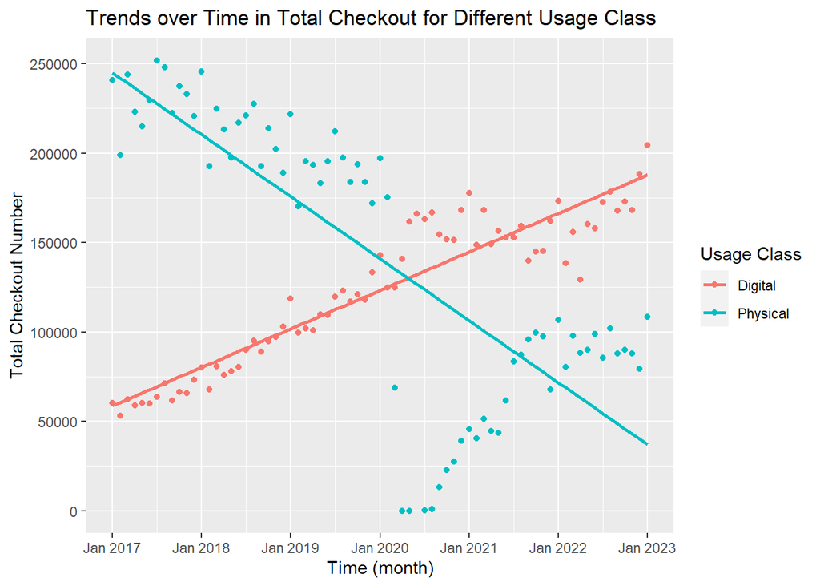

### Second Trends Over Time Chart

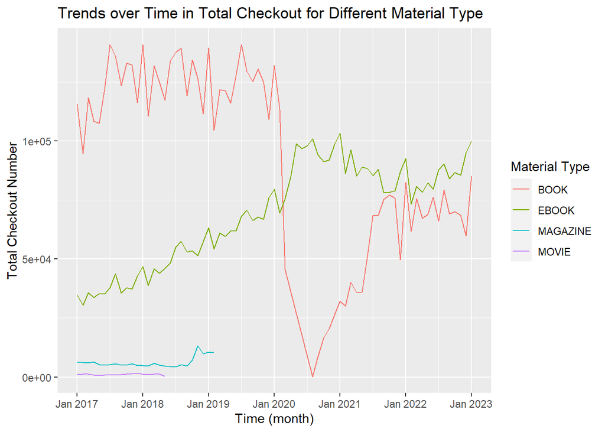

### Your Choice

The third chart was inspiration of one of my favorite book, The Hobbit. I was wondering how the total checkouts for the book changes monthly. The plot displayed the total checkout in The Hobbit for different month, while years are differently color coded. It seems like February usually has the lowest checkouts, while May and December has the highest.

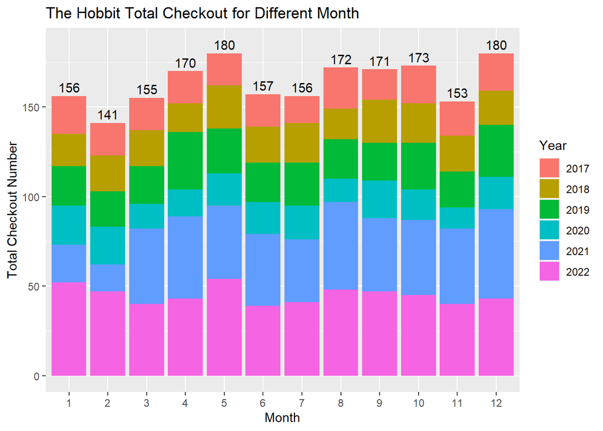